```python
from IPython.display import HTML
HTML('''<script src="https://cdnjs.cloudflare.com/ajax/libs/jquery/2.0.3/jquery.min.js "></script><script>
code_show=true;
function code_toggle() {
if (code_show){
$('div.jp-CodeCell > div.jp-Cell-inputWrapper').hide();
} else {
$('div.jp-CodeCell > div.jp-Cell-inputWrapper').show();
}
code_show = !code_show
}
$( document ).ready(code_toggle);</script><form action="javascript:code_toggle()"><input type="submit" value="Click here to toggle on/off the raw code."></form>
''')
```

[figure not shown]

```python
# For Data Prep
import numpy as np
import pandas as pd
import ast
import sqlite3
from sklearn import preprocessing
from sklearn.preprocessing import StandardScaler
from tqdm import tqdm
from collections import Counter
import datetime
from sklearn.feature_extraction.text import TfidfVectorizer
from sklearn.preprocessing import MultiLabelBinarizer
from wordcloud import WordCloud, STOPWORDS
from PIL import Image
from tqdm import trange

# For data scaling
from sklearn.preprocessing import StandardScaler
from scipy.stats import norm

# For Plotting
import matplotlib.pyplot as plt
import seaborn as sns
from itertools import cycle
import matplotlib.cm as cm
from plotly.subplots import make_subplots
import plotly.graph_objects as gob

from pyspark.sql import SparkSession
from pyspark import SparkConf
import pyspark.pandas as ps
import pandas as pd
from pyspark.sql.functions import (explode, desc, asc, round, log10, col,
                                   year, split, trim, lower)
import matplotlib.pyplot as plt

# For Warnings
import warnings
warnings.filterwarnings("ignore")

# For text processing
import nltk
nltk.download('stopwords')
from nltk.corpus import stopwords
stop_words = stopwords.words('english')
from pyspark.ml.feature import CountVectorizer, VectorSlicer
# from pyspark.ml.linalg import Vectors, SingularValueDecomposition
from sklearn.feature_extraction.text import TfidfVectorizer
```

# Executive Summary

The Stack Exchange network is a collection of community-driven question-and-answer websites covering a wide range of topics. This sets itself apart from other forums with its educational content and academic environment. With this unique setup, we want to analyze the user behavior and engagement patterns on Stack Exchange, and identify relevant topics being discussed in the comments. We do this by performing descriptive analysis and by applying Latent Semantic Analysis (LSA) on the comments to identify the relevant topics and describe the overall behavior of users in the comment section. We found that our overall descriptive analysis and LSA agrees that coding/programming topics are the most relevant in the comment sections. We also found that users are generally stick to a question and answer type of discussion likely due to heavy moderation in these forums. To improve this study further, we suggest applying the LSA using `spark.ml` functions to be able to handle processing the entire dataset.

# Problem Statement

The comments section of any internet platform can be a very mysterious and unpredictable place to the uninitiated. For the Stack Exxchange network we want to answer the following question:

- How can we analyze the user behavior and engagement patterns on Stack Exchange, and what insights can we derive from this analysis?

# Motivation

The motivation behind this research stems from our curiosity to understand how users engage on Stack Exchange comments. Online communities play a crucial role in shaping our digital interactions, and by delving into user behavior, we can uncover fascinating insights into social dynamics and community dynamics. By examining sentiments and attitudes towards various topics, we aim to gain a deeper understanding of user satisfaction and engagement levels. Moreover, this research has practical implications for content creators and businesses, as it provides valuable insights for enhancing user experiences and tailoring offerings to align with user interests. Ultimately, our exploration of user behavior on Stack Exchange comments aims to foster healthier online communities and create more meaningful interactions for users.

# Data Source

**Stack Exchange Data Dump**

This dataset is available in the jojie public dataset repository. It is an anonymized dumuserp of all user-contributed content on the Stack Exchange network. Each site is formatted as a separate archive consisting of XML files zipped via 7-zip using bzip2 compression. This work focuses on the forum comments. Below is a quick summary of the file contents.

Filepath: /mnt/data/public/stackexchange/Comments.xml

**Database Summary:**

- 19GB total file size
- Containing comments from 2008-2020

**Original Data Source**

The dataset can be downloaded from archive.org:

https://archive.org/details/stackexchange

### Comments Dataset

- This dataset contains the comment information. The content of this database is compiled from the comments from the different forums on the stack exchange network.

# Data Exploration

```python
!du -sch /mnt/data/public/stackexchange/*Comments*
```

```
19G	/mnt/data/public/stackexchange/Comments.xml
4.3G	/mnt/data/public/stackexchange/stackoverflow.com-Comments.7z
23G	total
```

```python
spark = SparkSession.builder \
    .appName("My App") \
    .config("spark.jars.packages", "com.databricks:spark-xml_2.12:0.13.0") \
    .getOrCreate()
```

```
:: loading settings :: url = jar:file:/usr/local/spark-3.3.2-bin-hadoop3/jars/ivy-2.5.1.jar!/org/apache/ivy/core/settings/ivysettings.xml
```

[output not shown]

[output not shown]

```
Setting default log level to "WARN".
To adjust logging level use sc.setLogLevel(newLevel). For SparkR, use setLogLevel(newLevel).
```

```python
df = spark.read \
    .format("xml") \
    .option("rowTag", "row") \
    .load("file:///mnt/data/public/stackexchange/Comments.xml")
```

```python
df.printSchema()
```

```
root
 |-- _CreationDate: timestamp (nullable = true)
 |-- _Id: long (nullable = true)
 |-- _PostId: long (nullable = true)
 |-- _Score: long (nullable = true)
 |-- _Text: string (nullable = true)
 |-- _UserDisplayName: string (nullable = true)
 |-- _UserId: long (nullable = true)
```

### Raw Data Description

**Table 1. Comments Raw Data Description**

[output not shown]

### Comment count

We are first interested with the activity most active user in the comment section.

```python
# User with the most comments
most_comments = (df.groupby(['_UserId', '_UserDisplayName'])
                 .count()
                 .orderBy(desc('count')))
most_comments.show()
```

```
[Stage 3:===============================================>           (4 + 1) / 5]
```

```
+-------+----------------+------+
|_UserId|_UserDisplayName| count|
+-------+----------------+------+
|1491895|            null|116169|
|  22656|            null| 82359|
|  17034|            null| 65557|
| 505088|            null| 63252|
|1415724|            null| 62277|
|1048572|            null| 61654|
|1144035|            null| 57246|
| 440558|            null| 54848|
| 100297|            null| 54669|
|  15168|            null| 53317|
| 207421|            null| 52019|
|3832970|            null| 50306|
| 571407|            null| 49734|
| 157247|            null| 48340|
| 560648|            null| 48041|
| 992484|            null| 47366|
|1175966|            null| 47203|
| 115145|            null| 46805|
| 218196|            null| 45745|
| 118068|            null| 43185|
+-------+----------------+------+
only showing top 20 rows
```

```python
# Number of comments distribution
comment_counts_df = (most_comments.withColumn('x', round(log10('count'), 1))
                     .groupby('x')
                     .count()
                     .orderBy('x')
                     .toPandas()
)
```

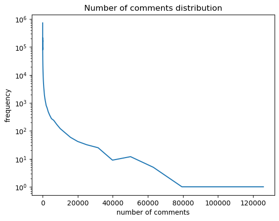

```python
plt.semilogy(10**comment_counts_df['x'], comment_counts_df['count'])
plt.title('Number of comments distribution')
plt.xlabel('number of comments')
plt.ylabel('frequency');
```

Here we can see further ahead the top commenter was compared to the rest with 116169 total comments. There are very few useres with over 80000 comments. Since users are anonymized, we use the `_UserID` to identify the top user. Here we look at the comments made by this most active user.

```python
# Most highly scored comments from the guy with the most comments
top_commenter_comments = (df.filter(df['_UserID'] == 1491895)
                          [['_UserID', '_UserDisplayName', '_Text', '_Score']]
                          .orderBy(desc('_Score')))
top_commenter_comments.show()
```

```
[Stage 4:======================================================>(596 + 1) / 597]
```

```
+-------+----------------+--------------------+------+
|_UserID|_UserDisplayName|               _Text|_Score|
+-------+----------------+--------------------+------+
|1491895|            null|Maybe `\d` deals ...|   174|
|1491895|            null|Don't use `list` ...|    66|
|1491895|            null|You shouldn't nam...|    50|
|1491895|            null|This shows all th...|    36|
|1491895|            null|I generally remem...|    31|
|1491895|            null|All together, wit...|    28|
|1491895|            null|In particular, th...|    24|
|1491895|            null|Maybe you want `i...|    22|
|1491895|            null|Rules for filenam...|    21|
|1491895|            null|If you're trying ...|    20|
|1491895|            null|There's no standa...|    18|
|1491895|            null|Based on the acce...|    18|
|1491895|            null|It's unlikely tha...|    17|
|1491895|            null|What a sucky sche...|    16|
|1491895|            null|How can a string ...|    16|
|1491895|            null|@jpmc26 This is n...|    16|
|1491895|            null|You avoid it by n...|    14|
|1491895|            null|Can you explain w...|    14|
|1491895|            null|And the first lin...|    14|
|1491895|            null|`=` has no specia...|    12|
+-------+----------------+--------------------+------+
only showing top 20 rows
```

As a glimpse on the kind of comments on the forum network, here's the top scoring comment made by the most active user.

```python
top_commenter_comments.first()['_Text']
```

```
'Maybe `\\d` deals with locales. E.g. Hebrew uses letters for digits.'
```

We can also take a look at the most highly scored comment.

```python
# Overall top scoring comments
top_scoring_comments = (df[['_UserID', '_UserDisplayName', '_Text', '_Score']]
                          .orderBy(desc('_Score'))
                        .limit(10))
top_scoring_comments.show()
```

```
[Stage 5:======================================================>(596 + 1) / 597]
```

```
+-------+----------------+--------------------+------+
|_UserID|_UserDisplayName|               _Text|_Score|
+-------+----------------+--------------------+------+
| 262683|            null|Did you really st...|  1459|
| 995110|            null|I google this eve...|  1362|
|1180620|            null|I am the referenc...|  1322|
| 757461|            null|Actually, this is...|  1242|
| 247542|            null|No one's saying i...|  1212|
| 123012|            null|This "goes to" op...|  1122|
|   7867|            null|Disagree.  It's t...|  1079|
|  20774|            null|Playing devil's a...|  1066|
| 102937|            null|***Moderator note...|  1016|
|   2988|            null|I think one canno...|  1008|
+-------+----------------+--------------------+------+
```

```python
top_scoring_comments.first()['_Text']
```

```
'Did you really stumble upon that exact situation in a real-life scenario or was this question only meant to be a puzzler -- just for the fun of it ?'
```

Looking at the two examples of comments, we can't really tell right away what the context of these comments are individually. Which is why LSA will be helpful in identifying relevant topics in the comments.

### Scores

Here we look at the distribution of scores for all comments.

```python
# Score distribution
score_counts = (df.withColumn('x', round(log10('_Score'), 1))
                .groupby('x')
                .count()
                .orderBy('x')
)
```

```python
score_counts_df = score_counts.toPandas()
```

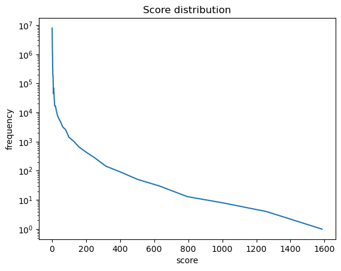

```python
plt.semilogy(10**score_counts_df['x'], score_counts_df['count'])
plt.title('Score distribution')
plt.xlabel('score')
plt.ylabel('frequency');
```

The scores appear to be distributed in a power law with a negative exponent which can be seen from the inverse logarithmic curve in the semi-log axis.

### Years

Here we look at the distribution of creation dates for these comments. By looking at this, we can get an idea of what where the most talked about topics during those years.

```python
# Comment year distribution
year_dist = (df.withColumn('year', year(df['_CreationDate']))
             .groupby('year')
             .count()
             .orderBy('year'))
```

```python
year_dist_df = year_dist.toPandas()
```

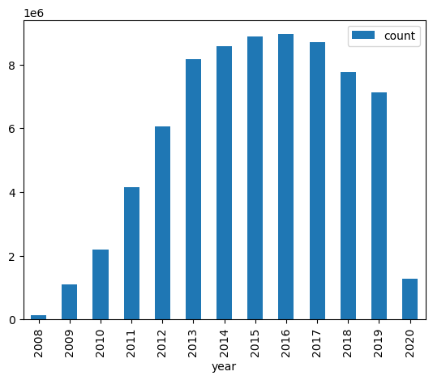

```python
year_dist_df.set_index('year').plot.bar()
```

We expect that the content of the comments should be relevant during the years 2012-2019.

# Methodology

[figure not shown]

We followed a systematic approach to analyze user behavior on Stack Exchange using the following steps:

By employing these methodologies, we gained comprehensive insights into user behavior on Stack Exchange. Our analysis involved cleaning the data, exploring patterns through EDA, understanding user sentiments, and uncovering the prevalent topics of discussion.

These findings serve as a solid foundation for further analysis, enabling us to make informed decisions based on user interactions within the Stack Exchange community.

# Descriptive Analytics: Sentiment analysis

We make use of the nltk stopwords to remove unwated tokens in our dataset. We then take a look at the most commonly appearing tokens out of all comments.

```python
# most common tokens while removing nltk stopwords
common_tokens = (df.withColumn('tokens', explode(split(trim(lower('_Text')),
                                                       r'\W+')))
                 .groupby('tokens')
                 .count()
                 .orderBy(desc('count'))
                 .filter(~col('tokens').isin(stop_words)))
```

```
[Stage 25:=============================================>          (13 + 3) / 16]
```

[output not shown]

```python
common_tokens_df = common_tokens.limit(20).toPandas()
```

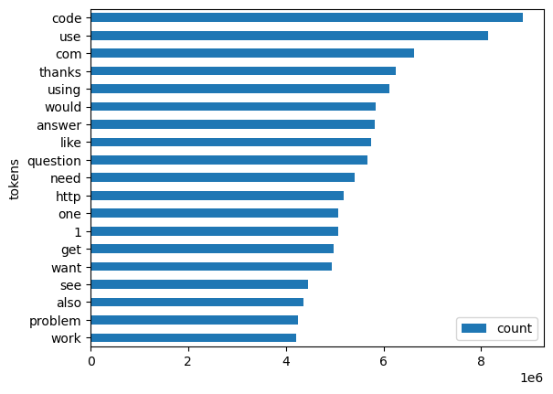

```python
(common_tokens_df.set_index('tokens').sort_values(by='count')
 .iloc[:-1].plot(kind='barh'))
```

It looks like `code` is the most frequently appearing token followed by words that are commonly used to answering questions such as `want`,`need`, `use`, and `using`. Such is the behavior of forums where questions are posted and the answers are usually in the comment section. Even `thanks` is there for when the question has been answered. Having `code` as the most frequent token suggests that the most common topic in the comments is answering questions about code.

For this next part, we apply Latent Semantic Analysis on the top scoring comments.

```python
# Overall top scoring comments
top_scoring_comments_1k = (df[['_UserID', '_UserDisplayName',
                               '_Text', '_Score']]
                          .orderBy(desc('_Score'))
                        .limit(1000))
top_scoring_comments_1k.show()
```

[output not shown]

```python
top_scoring_text = top_scoring_comments_1k.select(['_Text'])
top_scoring_text_df = top_scoring_text.toPandas()
```

```python
tfidf_vectorizer = TfidfVectorizer(token_pattern=r'[a-z-]+',
                                   stop_words='english',
                                   min_df=5)
```

```python
top_scoring_comments_text = top_scoring_text_df._Text.to_list()
```

```python
bow_comments = tfidf_vectorizer.fit_transform(top_scoring_comments_text)
nonzeros = bow_comments.sum(axis=1).nonzero()[0]
bow_comments = bow_comments[nonzeros]
```

```python
def truncated_svd(X):
    u, s, vh = np.linalg.svd(X)
    return u, np.diag(s), vh.T, (s**2)/(sum(s**2))
```

```python
(q_comments, s_comments,
 p_comments, nssd_comments) = truncated_svd(bow_comments.toarray())
```

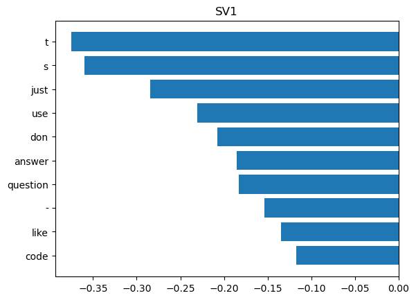

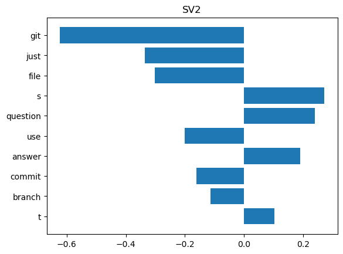

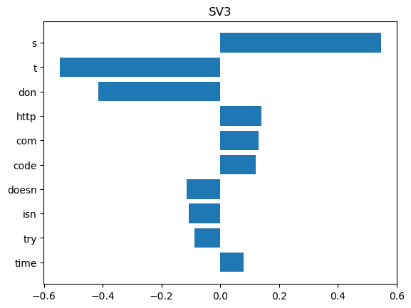

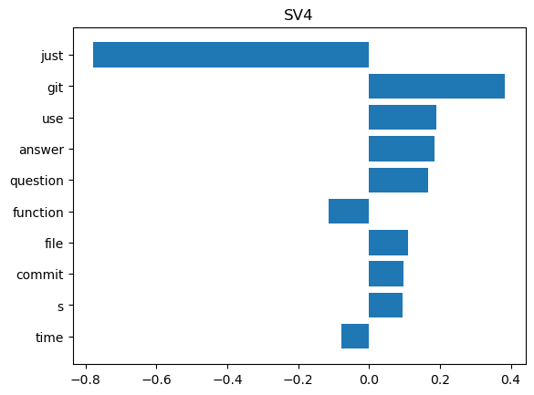

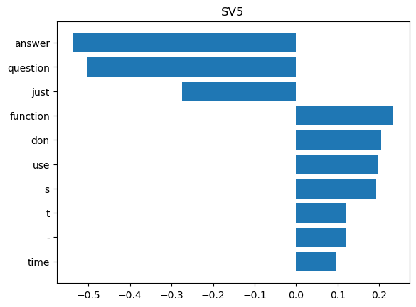

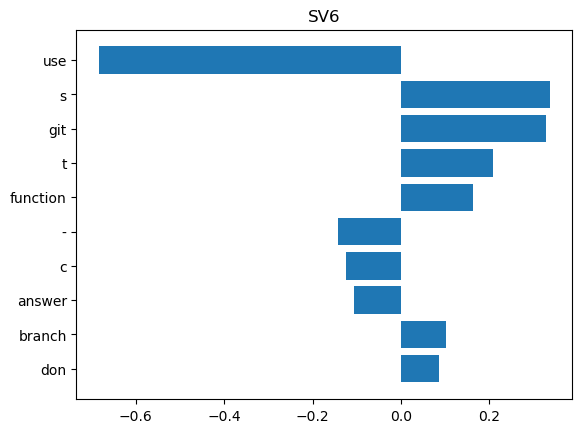

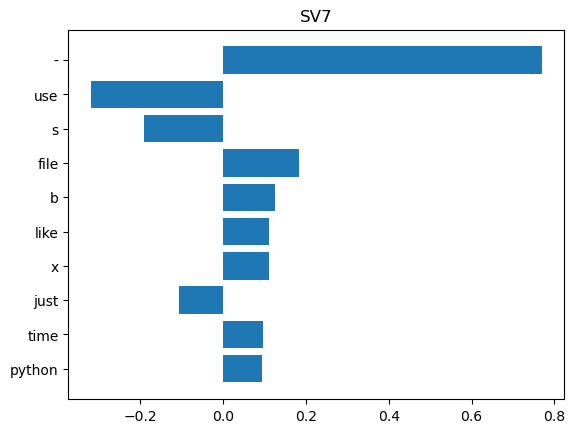

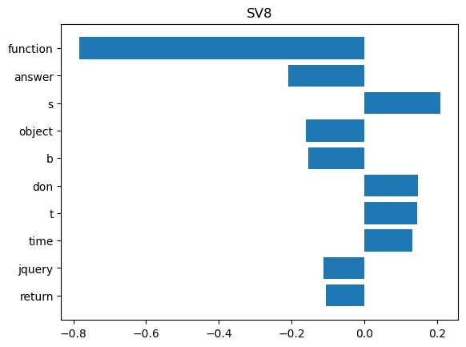

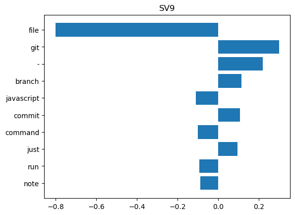

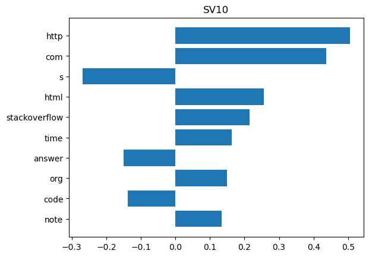

```python
feature_names = tfidf_vectorizer.get_feature_names_out()
for i in range(10):
    fig, ax = plt.subplots()
    order = np.argsort(np.abs(p_comments[:, i]))[-10:]
    ax.barh([feature_names[o] for o in order], p_comments[order, i])
    ax.set_title(f'SV{i+1}')
```

We can infer from the top 10 singular vectors, that the most relevant topics in the comment section is about coding/programming. More specific topics may include git, questions involving functions, and languages like Python, C, and Javascript. This can also be indicative of the activity of programming community in forums which far exceeds the activity in any other forums.

# Results and Discussions

The result of our LSA generally agrees with the insights from the descriptive analytics where we found that the top 10 singular vectors consistently refer to coding/programming related questions. We identified a few specific programming topics that were found to be relevant such as git commands, use of particular functions, and programming languages like Python, C, and Javascript. This unanimous result could also be indicative of the sheer amount of activity in forums within the programming community.

# Conclusion

In this study, we performed a descriptive analysis and applied Latent Semantic Analysis on comments in the Stack Exchange network. From the frequency of tokens, we found that coding question and answers are the most frequent topics in the comment section. This agrees with the results we got from LSA. Here we found that the top 10 singular vectors consistently refer to coding/programming related questions. We identified a few specific programming topics that were found to be relevant such as git commands, use of particular functions, and programming languages like Python, C, and Javascript. This unanimous result could also be indicative of the sheer amount of activity in forums within the programming community. Considering the years included in the dataset, programming questions are a reasonable hot topic. To summarize, by performing descriptive analytics and Latent Semanitc Analysis, we identified the most relevant topics in forums to be related to coding/programming. The behavior of users in the Stack Exchange network follow the pattern of answering questions unlike what we observe from other platforms. This might also indicate a heavy moderation in the discussions in the forums.

# Recommendations

There are several limitations we were able to identify in this study.

1. Comment data does not include information of which forum it came from. If we know this information, we could make more focused analysis on the comments for each forum.
2. Sentiment analysis was only performed on the top comments. Performing these methodologies on Spark will need additional libraries.

To address these limitations and further improve our study, we propose the following recommendations:

1. Explore the other files in the Stack Exchange dataset which could improve the context of the comments.
2. We could further explore the `pyspark.ml` module to allow us to perform LSA on the entire dataset.

# References

All references and sources are properly cited or acknowledged.

[1] SparkByExamples. (n.d.). Spark Read Write XML. Retrieved from https://sparkbyexamples.com/spark/spark-read-write-xml/

[2] Learn Share. (n.d.). How to Read and Write XML Files Using Spark. Retrieved from https://learn-share.com/post/how-to-read-and-write-xml-files-using-spark/Sorour,

[3] S. E., Mine, T., Goda, K., & Hirokawa, S. (2014). Efficiency of LSA and K-means in Predicting Students' Academic Performance Based on Their Comments Data. In Proceedings of the 6th International Conference on Computer Supported Education (CSEDU 2014) - Volume 3 (pp. 88-95). Retrieved from [https://files.ifi.uzh.ch/stiller/CLOSER%202014/CSEDU/CSEDU/Information%20Technologies%20Supporting%20Learning/Full%20Papers/CSEDU_2014_88_CR.pdf]